# TAD_test

#### Test of some TAD analysis with small test data sets 'TAD_test.bed' 'TAD_test2_bed' and 'TAD_test3_bed'

Future analysis to be done using this data: /dors/capra_lab/users/bentonml/enhancer_gain_loss/data/reg_domains/tad

```python
import pandas as pd
import numpy as np
import matplotlib.pyplot as plt
%matplotlib inline
#plt.rcParams['figure.figsize'] = [2, 10]
import seaborn as sns; sns.set(color_codes=True)
from IPython.core.interactiveshell import InteractiveShell
InteractiveShell.ast_node_interactivity = "all"
```

#### Import data

```python
TAD_test1 = pd.read_table('/dors/capra_lab/users/evonne/TAD/data/TAD_test.bed', header=0)
TAD_test1.columns = ['chr','start','stop']

TAD_test2 = pd.read_table('/dors/capra_lab/users/evonne/TAD/data/TAD_test2.bed', header=0)
TAD_test2.columns = ['chr','start','stop']

TAD_test3 = pd.read_table('/dors/capra_lab/users/evonne/TAD/data/TAD_test3.bed', header=0)
TAD_test3.columns = ['chr','start','stop']
```

#### Function to find base pair size between two TADs

use this to help determine a cutoff when staying two TADs are different

```python
def betweenTADsize(data_frame): # input: BED file coordinates

    diff = np.array([])

    for i in range(len(data_frame) - 1):
        if data_frame.loc[i + 1,'chr'] == data_frame.loc[i,'chr']:
            difference =  data_frame.loc[i + 1,'start'] - data_frame.loc[i,'stop']
            diff = np.append(diff, difference)

    return(pd.DataFrame(diff)) # returns data frame of the basepair size between TADs
```

|  | 0 |
| --- | --- |
| count | 9.800000e+01 |
| mean | 1.200000e+06 |
| std | 7.741813e+05 |
| min | 2.400000e+05 |
| 25% | 6.400000e+05 |
| 50% | 9.400000e+05 |
| 75% | 1.600000e+06 |
| max | 4.640000e+06 |

```
array([[<matplotlib.axes._subplots.AxesSubplot object at 0x7f2022f47550>]], dtype=object)
```

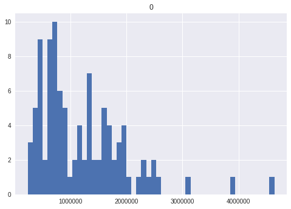

```python
diff = betweenTADsize(TAD_test1)
diff.describe()
diff.hist(bins=50)
```

From the above, it looks like all tads (in the small sample set) are > 240Kb away from each other, so I will set my buffer later to be around 100K (if start and end sites are within 100kb of each other, they represent the same TAD)

#### Merge all the TADs together in one

```python
out = pd.merge(TAD_test1, TAD_test2, how='outer')
out = pd.merge(out,TAD_test3,how='outer', sort=True)
len(out)
out.head()
```

```
238
```

|  | chr | start | stop |
| --- | --- | --- | --- |
| 0 | chr10 | 6000000 | 6040000 |
| 1 | chr10 | 6080000 | 6120000 |
| 2 | chr10 | 7760000 | 7800000 |
| 3 | chr10 | 7840000 | 7880000 |
| 4 | chr10 | 9360000 | 9400000 |

#### Create one master TAD list with intervals for TAD start and stop sites

```python
buffer = 100000

tmp = out.copy(deep=True)
TAD_total = []

while len(tmp) != 0:
    start = tmp.loc[0,'start']
    stop = tmp.loc[0,'stop']
    chrom = tmp.loc[0,'chr']
    start_min = start - buffer
    start_max = start + buffer
    stop_min = stop - buffer
    stop_max = stop + buffer
    tmp.drop(tmp[(tmp['chr'] == chrom) & (tmp['start'] > start_min) & (tmp['start'] < start_max) & (tmp['stop'] > stop_min) & (tmp['stop'] < stop_max)].index, inplace=True)
    tmp = tmp.reset_index(drop=True)
    TAD_total.append([chrom,start_min,start_max,stop_min,stop_max])

TAD_total = pd.DataFrame(np.vstack(TAD_total))
TAD_total.columns = ['chr','start_min','start_max','stop_min','stop_max']

TAD_total = TAD_total.apply(pd.to_numeric, errors = 'ignore')
```

```python
TAD_total.head()
len(TAD_total)
```

|  | chr | start_min | start_max | stop_min | stop_max |
| --- | --- | --- | --- | --- | --- |
| 0 | chr10 | 5900000 | 6100000 | 5940000 | 6140000 |
| 1 | chr10 | 7660000 | 7860000 | 7700000 | 7900000 |
| 2 | chr10 | 9260000 | 9460000 | 9300000 | 9500000 |
| 3 | chr10 | 11780000 | 11980000 | 11820000 | 12020000 |
| 4 | chr10 | 11900000 | 12100000 | 11940000 | 12140000 |

```
151
```

#### Function to run through a bed and add a column to the master TAD list, 1 represents that TAD does exist in the bed file, and 0 represents that it does not exist

```python
def findTADinCellTypes(data_frame, stringOfCellTypeName, TAD_total): # input: BED file coordinates data frame and a string describing the celltype the TAD data is from, TAD_total dataframe will all possible TADs


    TAD_total[stringOfCellTypeName] = 0

    for i in range(len(data_frame)):
        index = TAD_total[(TAD_total['chr'] == data_frame.loc[i,'chr']) & (TAD_total['start_min'] < data_frame.loc[i,'start']) & (TAD_total['start_max'] > data_frame.loc[i,'start']) & (TAD_total['stop_min'] < data_frame.loc[i,'stop']) & (TAD_total['stop_max'] > data_frame.loc[i,'stop'])].index
        TAD_total.loc[index,stringOfCellTypeName] = 1
    return TAD_total
```

```python
TAD_total = findTADinCellTypes(TAD_test1,'celltype1',TAD_total)
TAD_total = findTADinCellTypes(TAD_test2,'celltype2',TAD_total)
TAD_total = findTADinCellTypes(TAD_test3,'celltype3',TAD_total)
TAD_total.head()
len(TAD_total)
```

|  | chr | start_min | start_max | stop_min | stop_max | celltype1 | celltype2 | celltype3 |
| --- | --- | --- | --- | --- | --- | --- | --- | --- |
| 0 | chr10 | 5900000 | 6100000 | 5940000 | 6140000 | 1 | 1 | 1 |
| 1 | chr10 | 7660000 | 7860000 | 7700000 | 7900000 | 1 | 1 | 1 |
| 2 | chr10 | 9260000 | 9460000 | 9300000 | 9500000 | 1 | 1 | 1 |
| 3 | chr10 | 11780000 | 11980000 | 11820000 | 12020000 | 0 | 1 | 0 |
| 4 | chr10 | 11900000 | 12100000 | 11940000 | 12140000 | 1 | 0 | 1 |

```
151
```

#### Cluster the different cell types and TADs to see which cell types have similar TAD profiles and which TADs usually occur together in the same cell type

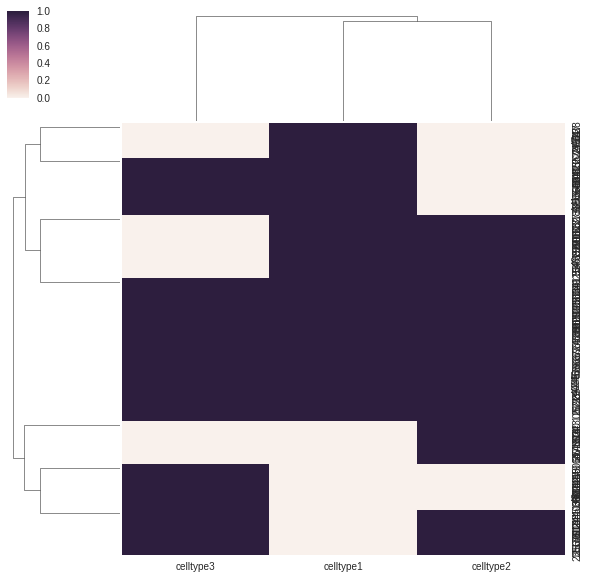

```python
g = sns.clustermap(TAD_total.drop(['chr','start_min','start_max','stop_min','stop_max'],axis=1))
```